# Исследование закономерностей, определяющих успешность игры

## Описание проекта

Интернет-магазин «Стримчик» продаёт по всему миру компьютерные игры. Из открытых источников доступны исторические данные о продажах игр, оценки пользователей и экспертов, жанры и платформы (например, Xbox или PlayStation).

**Цель исследования** - выявить определяющие успешность игры закономерности.

**Задачи исследования:**

- сравнить продажи по платформам в динамике и выявить актуальный период для целей прогнозирования продаж;
- составить портрет пользователя каждого региона;
- проверить гипотезы про пользовательские рейтинги.

**Ход исследования:**

В первую очередь откроем файл и подготовим данные для анализа. Заменим некорректные названия столбцов, преобразуем данные в нужные типы, обработаем пропуски и проверим наличие дубликатов и аномалий. В разделе исследовательский анализ данных посмотрим, как менялись продажи по платформам и определим их "жизненный срок". На основе полученных результатов выявим актуальный период для целей прогнозирования продаж. Далее рассмотрим жанры с высокой и низкой прибылью, а также оценим корреляцию между отзывами и продажами.

Определим для пользователей каждого региона:

- самые популярные платформы (топ-5);
- самые популярные жанры (топ-5);
- как влияет рейтинг ESRB на продажи.

В основной части исследования проверим следующие гипотезы:

- Средние пользовательские рейтинги платформ Xbox One и PC одинаковые;
- Средние пользовательские рейтинги жанров Action (англ. «действие», экшен-игры) и Sports (англ. «спортивные соревнования») разные.

В конце напишем общий вывод по результатам анализа.

Результаты исследования позволят понять, на какой потенциально популярный продукт сделать ставку и спланировать рекламные кампании. В нашем распоряжении данные до 2016 года. Представим, что сейчас декабрь 2016 г., и мы планируем кампанию на 2017-й. Нужно отработать принцип работы с данными. Неважно, прогнозируем ли мы продажи на 2017 год по данным 2016-го или же 2027-й — по данным 2026 года.

В наборе данных попадается аббревиатура ESRB (Entertainment Software Rating Board) — это ассоциация, определяющая возрастной рейтинг компьютерных игр. ESRB оценивает игровой контент и присваивает ему подходящую возрастную категорию, например, «Для взрослых», «Для детей младшего возраста» или «Для подростков».

## Изучение общей информации

```python
import pandas as pd
import seaborn as sns
import matplotlib.pyplot as plt
import matplotlib
import numpy as np
from scipy import stats as st
from matplotlib.ticker import (MultipleLocator, FormatStrFormatter, AutoMinorLocator)
# импорт библиотек pandas, seaborn, matplotlib.pyplot, numpy, stats
%config InlineBackend.figure_format='jpg'
import warnings
warnings.filterwarnings('ignore')
```

```python
games_df = pd.read_csv('/Users/polzovatel/Desktop/Проекты Яндекс доработка/Games hypotheses/games.csv')
# чтение файла с данными и сохранение в games_df
```

```python
def get_df_info(df):
    display(df.head(10))
    display(df.info())
    display(df.describe())
# создание функции для вывода характеристик датафрейма
```

```python
get_df_info(games_df)
# применение функции get_df_info
```

|  | Name | Platform | Year_of_Release | Genre | NA_sales | EU_sales | JP_sales | Other_sales | Critic_Score | User_Score | Rating |
| --- | --- | --- | --- | --- | --- | --- | --- | --- | --- | --- | --- |
| 0 | Wii Sports | Wii | 2006.0 | Sports | 41.36 | 28.96 | 3.77 | 8.45 | 76.0 | 8 | E |
| 1 | Super Mario Bros. | NES | 1985.0 | Platform | 29.08 | 3.58 | 6.81 | 0.77 | NaN | NaN | NaN |
| 2 | Mario Kart Wii | Wii | 2008.0 | Racing | 15.68 | 12.76 | 3.79 | 3.29 | 82.0 | 8.3 | E |
| 3 | Wii Sports Resort | Wii | 2009.0 | Sports | 15.61 | 10.93 | 3.28 | 2.95 | 80.0 | 8 | E |
| 4 | Pokemon Red/Pokemon Blue | GB | 1996.0 | Role-Playing | 11.27 | 8.89 | 10.22 | 1.00 | NaN | NaN | NaN |
| 5 | Tetris | GB | 1989.0 | Puzzle | 23.20 | 2.26 | 4.22 | 0.58 | NaN | NaN | NaN |
| 6 | New Super Mario Bros. | DS | 2006.0 | Platform | 11.28 | 9.14 | 6.50 | 2.88 | 89.0 | 8.5 | E |
| 7 | Wii Play | Wii | 2006.0 | Misc | 13.96 | 9.18 | 2.93 | 2.84 | 58.0 | 6.6 | E |
| 8 | New Super Mario Bros. Wii | Wii | 2009.0 | Platform | 14.44 | 6.94 | 4.70 | 2.24 | 87.0 | 8.4 | E |
| 9 | Duck Hunt | NES | 1984.0 | Shooter | 26.93 | 0.63 | 0.28 | 0.47 | NaN | NaN | NaN |

```
<class 'pandas.core.frame.DataFrame'>
RangeIndex: 16715 entries, 0 to 16714
Data columns (total 11 columns):
 #   Column           Non-Null Count  Dtype
---  ------           --------------  -----
 0   Name             16713 non-null  object
 1   Platform         16715 non-null  object
 2   Year_of_Release  16446 non-null  float64
 3   Genre            16713 non-null  object
 4   NA_sales         16715 non-null  float64
 5   EU_sales         16715 non-null  float64
 6   JP_sales         16715 non-null  float64
 7   Other_sales      16715 non-null  float64
 8   Critic_Score     8137 non-null   float64
 9   User_Score       10014 non-null  object
 10  Rating           9949 non-null   object
dtypes: float64(6), object(5)
memory usage: 1.4+ MB
```

```
None
```

|  | Year_of_Release | NA_sales | EU_sales | JP_sales | Other_sales | Critic_Score |
| --- | --- | --- | --- | --- | --- | --- |
| count | 16446.000000 | 16715.000000 | 16715.000000 | 16715.000000 | 16715.000000 | 8137.000000 |
| mean | 2006.484616 | 0.263377 | 0.145060 | 0.077617 | 0.047342 | 68.967679 |
| std | 5.877050 | 0.813604 | 0.503339 | 0.308853 | 0.186731 | 13.938165 |
| min | 1980.000000 | 0.000000 | 0.000000 | 0.000000 | 0.000000 | 13.000000 |
| 25% | 2003.000000 | 0.000000 | 0.000000 | 0.000000 | 0.000000 | 60.000000 |
| 50% | 2007.000000 | 0.080000 | 0.020000 | 0.000000 | 0.010000 | 71.000000 |
| 75% | 2010.000000 | 0.240000 | 0.110000 | 0.040000 | 0.030000 | 79.000000 |
| max | 2016.000000 | 41.360000 | 28.960000 | 10.220000 | 10.570000 | 98.000000 |

Стоит отметить проблемы в названиях колонок. Они должны быть записаны строчными буквами.

В столбцах `critic_score`, `user_score` и `rating` отсутствует почти половина данных.

Данные в `year_of_release` представлены типом float64, а в оценках пользователей `user_score` кроме числовых значений присутствуют значения типа "str".

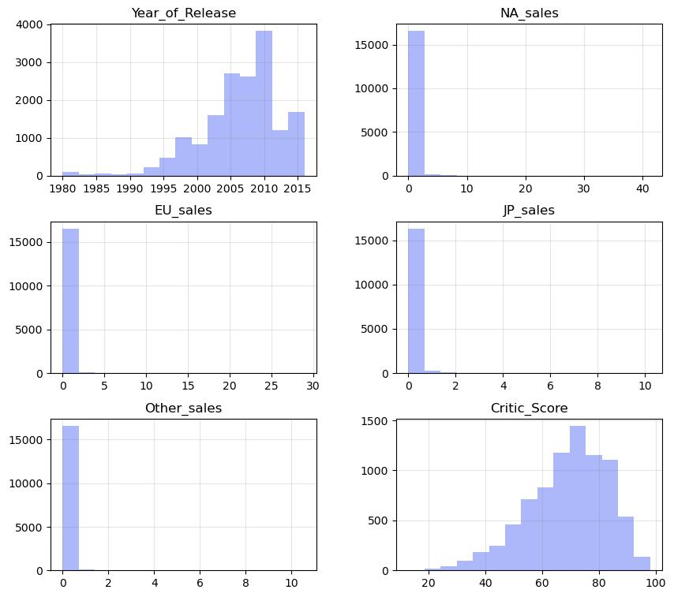

```python
matplotlib.rcParams['grid.color'] = 'gray'
matplotlib.rcParams['grid.alpha'] = 0.2
ax = games_df.hist(figsize=(10, 9), color='#acb8fa', bins=15)
# вывод гистограмм для всех числовых столбцов таблицы
```

### Вывод

В каждой строке таблицы - данные о продаже компьютерных игр за период до 2016 года. Часть колонок содержит информацию относительно характеристик игры: жанра, платформы, оценки пользователей и критиков, возрастного рейтинга. Другие данные подробнее знакомят нас с продажами в зависимости от регионов и стран.

В датафрейме есть значения с некорректным типом, а также пропуски в нескольких колонках.

В первую очередь устраним проблемы в данных.

## Предобработка данных

### Замена названий столбцов

Заменим прописные буквы в названиях столбцов на строчные.

```python
games_df.columns = games_df.columns.str.lower()
# приведение символов к нижнему регистру
```

```python
games_df.columns
# информация о названиях столбцов
```

```
Index(['name', 'platform', 'year_of_release', 'genre', 'na_sales', 'eu_sales',
       'jp_sales', 'other_sales', 'critic_score', 'user_score', 'rating'],
      dtype='object')
```

### Удаление дубликатов

```python
print(games_df.duplicated().sum())
# подсчёт явных дубликатов
```

```
0
```

Явных дубликатов нет.

Проверим, есть ли среди названий игр неявные дубликаты. Одна и та же игра могла быть выпущена для разных платформ в разные годы. Поэтому для поиска повторов выделим срез данных со столбцами `name`, `platform`, `year_of_release`, `genre`.

```python
games_df_duplicates = games_df[games_df[['name', 'platform', 'year_of_release', 'genre']].duplicated()]
games_df_duplicates
# поиск повторяющихся значений
```

|  | name | platform | year_of_release | genre | na_sales | eu_sales | jp_sales | other_sales | critic_score | user_score | rating |
| --- | --- | --- | --- | --- | --- | --- | --- | --- | --- | --- | --- |
| 14244 | NaN | GEN | 1993.0 | NaN | 0.0 | 0.00 | 0.03 | 0.0 | NaN | NaN | NaN |
| 16230 | Madden NFL 13 | PS3 | 2012.0 | Sports | 0.0 | 0.01 | 0.00 | 0.0 | 83.0 | 5.5 | E |

```python
games_df[(games_df['name'] == 'Madden NFL 13') & (games_df['platform'] == 'PS3')]
# получение среза данных
```

|  | name | platform | year_of_release | genre | na_sales | eu_sales | jp_sales | other_sales | critic_score | user_score | rating |
| --- | --- | --- | --- | --- | --- | --- | --- | --- | --- | --- | --- |
| 604 | Madden NFL 13 | PS3 | 2012.0 | Sports | 2.11 | 0.22 | 0.0 | 0.23 | 83.0 | 5.5 | E |
| 16230 | Madden NFL 13 | PS3 | 2012.0 | Sports | 0.00 | 0.01 | 0.0 | 0.00 | 83.0 | 5.5 | E |

Информация об игре "Madden NFL 13" была занесена в таблицу 2 раза. В одной из строк присутствует дополнительная информация о продажах в Европе. Чтобы не потерять данные, сохраним сумму продаж в Европе по этим двум стокам в отдельную переменную и после удаления дубликата обновим данные.

```python
madden_nfl_13_sales = games_df.loc[16230, 'eu_sales'] + games_df.loc[604, 'eu_sales']
# сохранение в переменную суммы продаж
```

```python
games_df[games_df['name'].isna()]
# получение среза данных
```

|  | name | platform | year_of_release | genre | na_sales | eu_sales | jp_sales | other_sales | critic_score | user_score | rating |
| --- | --- | --- | --- | --- | --- | --- | --- | --- | --- | --- | --- |
| 659 | NaN | GEN | 1993.0 | NaN | 1.78 | 0.53 | 0.00 | 0.08 | NaN | NaN | NaN |
| 14244 | NaN | GEN | 1993.0 | NaN | 0.00 | 0.00 | 0.03 | 0.00 | NaN | NaN | NaN |

Наблюдаем такую же ситуацию, как и с игрой "Madden NFL 13".

```python
nan_sales = games_df.loc[14244, 'jp_sales'] + games_df.loc[659, 'jp_sales']
# сохранение в переменную суммы продаж
```

Удаляем неявные дубликаты.

```python
games_df = games_df[~(games_df.index.isin(games_df_duplicates.index))]
# сохранение среза данных
```

```python
games_df.loc[604, 'eu_sales'] = madden_nfl_13_sales
games_df.loc[659, 'jp_sales'] = nan_sales
# замена значений с помощью атрибута loc
```

```python
games_df['platform'].unique()
# просмотр уникальных наименований платформ
```

```
array(['Wii', 'NES', 'GB', 'DS', 'X360', 'PS3', 'PS2', 'SNES', 'GBA',
       'PS4', '3DS', 'N64', 'PS', 'XB', 'PC', '2600', 'PSP', 'XOne',
       'WiiU', 'GC', 'GEN', 'DC', 'PSV', 'SAT', 'SCD', 'WS', 'NG', 'TG16',
       '3DO', 'GG', 'PCFX'], dtype=object)
```

```python
games_df['platform'].value_counts()
# количество уникальных совпадений в колонке 'platform'
```

```
PS2     2161
DS      2151
PS3     1330
Wii     1320
X360    1262
PSP     1209
PS      1197
PC       974
XB       824
GBA      822
GC       556
3DS      520
PSV      430
PS4      392
N64      319
XOne     247
SNES     239
SAT      173
WiiU     147
2600     133
NES       98
GB        98
DC        52
GEN       28
NG        12
SCD        6
WS         6
3DO        3
TG16       2
GG         1
PCFX       1
Name: platform, dtype: int64
```

```python
games_df['rating'].value_counts()
# количество уникальных совпадений в колонке 'rating'
```

```
E       3989
T       2961
M       1563
E10+    1420
EC         8
K-A        3
RP         3
AO         1
Name: rating, dtype: int64
```

Среди рейтингов ESRB есть устаревший рейтинг "K-A" ("Kids to Adults"). В данный момент его уже не используют. По своему описанию он соответствует рейтингу "E" ("Everyone"). Добавим игры с "K-A" в категорию "E".

```python
games_df['rating'] = games_df['rating'].replace('K-A', 'E')
# замена рейтинга в столбце 'rating'
```

```python
games_df['rating'].value_counts()
# проверка количества уникальных совпадений в колонке 'rating'
```

```
E       3992
T       2961
M       1563
E10+    1420
EC         8
RP         3
AO         1
Name: rating, dtype: int64
```

```python
games_df['genre'].value_counts()
# количество уникальных совпадений в колонке 'genre'
```

```
Action          3369
Sports          2347
Misc            1750
Role-Playing    1498
Shooter         1323
Adventure       1303
Racing          1249
Platform         888
Simulation       873
Fighting         849
Strategy         683
Puzzle           580
Name: genre, dtype: int64
```

### Заполнение пропусков

```python
games_df.info()
# получение общей информации о данных в таблице games_df
```

```
<class 'pandas.core.frame.DataFrame'>
Int64Index: 16713 entries, 0 to 16714
Data columns (total 11 columns):
 #   Column           Non-Null Count  Dtype
---  ------           --------------  -----
 0   name             16712 non-null  object
 1   platform         16713 non-null  object
 2   year_of_release  16444 non-null  float64
 3   genre            16712 non-null  object
 4   na_sales         16713 non-null  float64
 5   eu_sales         16713 non-null  float64
 6   jp_sales         16713 non-null  float64
 7   other_sales      16713 non-null  float64
 8   critic_score     8136 non-null   float64
 9   user_score       10013 non-null  object
 10  rating           9948 non-null   object
dtypes: float64(6), object(5)
memory usage: 2.0+ MB
```

```python
games_df[games_df['name'].isna()].head()
# просмотр первых пяти строк с пропусками в столбце 'name'
```

|  | name | platform | year_of_release | genre | na_sales | eu_sales | jp_sales | other_sales | critic_score | user_score | rating |
| --- | --- | --- | --- | --- | --- | --- | --- | --- | --- | --- | --- |
| 659 | NaN | GEN | 1993.0 | NaN | 1.78 | 0.53 | 0.03 | 0.08 | NaN | NaN | NaN |

Пропуск в столбце `name` мог появиться в результате сбоя в автоматизированной системе сбора информации или на этапе выгрузки данных. Заменить его по имеющимся данным не получится, оставим как есть.

```python
games_df[games_df['year_of_release'].isna()].head()
# просмотр первых пяти строк с пропусками в столбце 'year_of_release'
```

|  | name | platform | year_of_release | genre | na_sales | eu_sales | jp_sales | other_sales | critic_score | user_score | rating |
| --- | --- | --- | --- | --- | --- | --- | --- | --- | --- | --- | --- |
| 183 | Madden NFL 2004 | PS2 | NaN | Sports | 4.26 | 0.26 | 0.01 | 0.71 | 94.0 | 8.5 | E |
| 377 | FIFA Soccer 2004 | PS2 | NaN | Sports | 0.59 | 2.36 | 0.04 | 0.51 | 84.0 | 6.4 | E |
| 456 | LEGO Batman: The Videogame | Wii | NaN | Action | 1.80 | 0.97 | 0.00 | 0.29 | 74.0 | 7.9 | E10+ |
| 475 | wwe Smackdown vs. Raw 2006 | PS2 | NaN | Fighting | 1.57 | 1.02 | 0.00 | 0.41 | NaN | NaN | NaN |
| 609 | Space Invaders | 2600 | NaN | Shooter | 2.36 | 0.14 | 0.00 | 0.03 | NaN | NaN | NaN |

```python
games_df[games_df['year_of_release'].isna()].shape
# вызов атрибута shape с количеством строк и столбцов
```

```
(269, 11)
```

Пропущенные значения в `year_of_release` нельзя восстановить, так как они уникальны для каждой игры. Можно удалить такие строки, ведь их доля составляет 1.6% всех данных.

```python
games_df = games_df[~(games_df['year_of_release'].isna())]
# сохранение среза данных
```

```python
games_df[games_df['genre'].isna()].head()
# просмотр первых пяти строк с пропусками в столбце 'genre'
```

|  | name | platform | year_of_release | genre | na_sales | eu_sales | jp_sales | other_sales | critic_score | user_score | rating |
| --- | --- | --- | --- | --- | --- | --- | --- | --- | --- | --- | --- |
| 659 | NaN | GEN | 1993.0 | NaN | 1.78 | 0.53 | 0.03 | 0.08 | NaN | NaN | NaN |

```python
games_df[games_df['user_score'].isna()].head()
# просмотр первых пяти строк с пропусками в столбце 'user_score'
```

|  | name | platform | year_of_release | genre | na_sales | eu_sales | jp_sales | other_sales | critic_score | user_score | rating |
| --- | --- | --- | --- | --- | --- | --- | --- | --- | --- | --- | --- |
| 1 | Super Mario Bros. | NES | 1985.0 | Platform | 29.08 | 3.58 | 6.81 | 0.77 | NaN | NaN | NaN |
| 4 | Pokemon Red/Pokemon Blue | GB | 1996.0 | Role-Playing | 11.27 | 8.89 | 10.22 | 1.00 | NaN | NaN | NaN |
| 5 | Tetris | GB | 1989.0 | Puzzle | 23.20 | 2.26 | 4.22 | 0.58 | NaN | NaN | NaN |
| 9 | Duck Hunt | NES | 1984.0 | Shooter | 26.93 | 0.63 | 0.28 | 0.47 | NaN | NaN | NaN |
| 10 | Nintendogs | DS | 2005.0 | Simulation | 9.05 | 10.95 | 1.93 | 2.74 | NaN | NaN | NaN |

```python
games_df['user_score'].unique()
# просмотр уникальных значений в столбце 'user_score'
```

```
array(['8', nan, '8.3', '8.5', '6.6', '8.4', '8.6', '7.7', '6.3', '7.4',
       '8.2', '9', '7.9', '8.1', '8.7', '7.1', '3.4', '5.3', '4.8', '3.2',
       '8.9', '6.4', '7.8', '7.5', '2.6', '7.2', '9.2', '7', '7.3', '4.3',
       '7.6', '5.7', '5', '9.1', '6.5', 'tbd', '8.8', '6.9', '9.4', '6.8',
       '6.1', '6.7', '5.4', '4', '4.9', '4.5', '9.3', '6.2', '4.2', '6',
       '3.7', '4.1', '5.8', '5.6', '5.5', '4.4', '4.6', '5.9', '3.9',
       '3.1', '2.9', '5.2', '3.3', '4.7', '5.1', '3.5', '2.5', '1.9', '3',
       '2.7', '2.2', '2', '9.5', '2.1', '3.6', '2.8', '1.8', '3.8', '0',
       '1.6', '9.6', '2.4', '1.7', '1.1', '0.3', '1.5', '0.7', '1.2',
       '2.3', '0.5', '1.3', '0.2', '0.6', '1.4', '0.9', '1', '9.7'],
      dtype=object)
```

В колонке с числовыми оценками пользователей встречается значение "tbd". Аббревиатура "tbd" или "to be determined" означает, что рейтинг игре пока не присвоен или будет определён позже, а пока значение не известно. Заменим такие значения на nan.

```python
games_df['user_score'] = games_df['user_score'].replace('tbd', np.nan)
# замена 'tbd' в столбце 'user_score' на nan
```

```python
games_df['user_score'].unique()
# проверка уникальных значений в столбце 'user_score'
```

```
array(['8', nan, '8.3', '8.5', '6.6', '8.4', '8.6', '7.7', '6.3', '7.4',
       '8.2', '9', '7.9', '8.1', '8.7', '7.1', '3.4', '5.3', '4.8', '3.2',
       '8.9', '6.4', '7.8', '7.5', '2.6', '7.2', '9.2', '7', '7.3', '4.3',
       '7.6', '5.7', '5', '9.1', '6.5', '8.8', '6.9', '9.4', '6.8', '6.1',
       '6.7', '5.4', '4', '4.9', '4.5', '9.3', '6.2', '4.2', '6', '3.7',
       '4.1', '5.8', '5.6', '5.5', '4.4', '4.6', '5.9', '3.9', '3.1',
       '2.9', '5.2', '3.3', '4.7', '5.1', '3.5', '2.5', '1.9', '3', '2.7',
       '2.2', '2', '9.5', '2.1', '3.6', '2.8', '1.8', '3.8', '0', '1.6',
       '9.6', '2.4', '1.7', '1.1', '0.3', '1.5', '0.7', '1.2', '2.3',
       '0.5', '1.3', '0.2', '0.6', '1.4', '0.9', '1', '9.7'], dtype=object)
```

```python
games_df[games_df['critic_score'].isna()].head()
# просмотр первых пяти строк с пропусками в столбце 'critic_score'
```

|  | name | platform | year_of_release | genre | na_sales | eu_sales | jp_sales | other_sales | critic_score | user_score | rating |
| --- | --- | --- | --- | --- | --- | --- | --- | --- | --- | --- | --- |
| 1 | Super Mario Bros. | NES | 1985.0 | Platform | 29.08 | 3.58 | 6.81 | 0.77 | NaN | NaN | NaN |
| 4 | Pokemon Red/Pokemon Blue | GB | 1996.0 | Role-Playing | 11.27 | 8.89 | 10.22 | 1.00 | NaN | NaN | NaN |
| 5 | Tetris | GB | 1989.0 | Puzzle | 23.20 | 2.26 | 4.22 | 0.58 | NaN | NaN | NaN |
| 9 | Duck Hunt | NES | 1984.0 | Shooter | 26.93 | 0.63 | 0.28 | 0.47 | NaN | NaN | NaN |
| 10 | Nintendogs | DS | 2005.0 | Simulation | 9.05 | 10.95 | 1.93 | 2.74 | NaN | NaN | NaN |

```python
games_df[games_df['rating'].isna()].head()
# просмотр первых пяти строк с пропусками в столбце 'rating'
```

|  | name | platform | year_of_release | genre | na_sales | eu_sales | jp_sales | other_sales | critic_score | user_score | rating |
| --- | --- | --- | --- | --- | --- | --- | --- | --- | --- | --- | --- |
| 1 | Super Mario Bros. | NES | 1985.0 | Platform | 29.08 | 3.58 | 6.81 | 0.77 | NaN | NaN | NaN |
| 4 | Pokemon Red/Pokemon Blue | GB | 1996.0 | Role-Playing | 11.27 | 8.89 | 10.22 | 1.00 | NaN | NaN | NaN |
| 5 | Tetris | GB | 1989.0 | Puzzle | 23.20 | 2.26 | 4.22 | 0.58 | NaN | NaN | NaN |
| 9 | Duck Hunt | NES | 1984.0 | Shooter | 26.93 | 0.63 | 0.28 | 0.47 | NaN | NaN | NaN |
| 10 | Nintendogs | DS | 2005.0 | Simulation | 9.05 | 10.95 | 1.93 | 2.74 | NaN | NaN | NaN |

```python
games_df.groupby('year_of_release')['rating'].count()
# подсчёт числа игр с присвоенным возрастным рейтингом
```

```
year_of_release
1980.0       0
1981.0       0
1982.0       0
1983.0       0
1984.0       0
1985.0       1
1986.0       0
1987.0       0
1988.0       1
1989.0       0
1990.0       0
1991.0       0
1992.0       2
1993.0       0
1994.0       1
1995.0       0
1996.0       7
1997.0      19
1998.0      32
1999.0      42
2000.0     148
2001.0     339
2002.0     655
2003.0     613
2004.0     598
2005.0     706
2006.0     678
2007.0     821
2008.0     981
2009.0    1011
2010.0     799
2011.0     703
2012.0     354
2013.0     316
2014.0     345
2015.0     315
2016.0     280
Name: rating, dtype: int64
```

Возрастной рейтинг "ESRB" начали присваивать играм с момента основания самой организации "ESRB" в 1994 г. Вероятно, данные за 1985, 1988 и 1992 гг. - это рейтинги, добавленные "ESRB" уже после начала деятельности ассоциации. Кроме того, "ESRB" специализируется на определении рейтингов преимущественно в США и Канаде.

Чтобы не потерять данные в ходе анализа и выделить их в отдельную группу, заменим пропущенные значения на "tbd".

```python
games_df['rating'] = games_df['rating'].fillna('tbd')
# замена пропущенных значений
```

```python
games_df.info()
# проверка общей информации о данных в таблице games_df
```

```
<class 'pandas.core.frame.DataFrame'>
Int64Index: 16444 entries, 0 to 16714
Data columns (total 11 columns):
 #   Column           Non-Null Count  Dtype
---  ------           --------------  -----
 0   name             16443 non-null  object
 1   platform         16444 non-null  object
 2   year_of_release  16444 non-null  float64
 3   genre            16443 non-null  object
 4   na_sales         16444 non-null  float64
 5   eu_sales         16444 non-null  float64
 6   jp_sales         16444 non-null  float64
 7   other_sales      16444 non-null  float64
 8   critic_score     7982 non-null   float64
 9   user_score       7462 non-null   object
 10  rating           16444 non-null  object
dtypes: float64(6), object(5)
memory usage: 1.5+ MB
```

### Изменение типов данных

```python
games_df.dtypes
# вызов атрибута dtypes с типами данных
```

```
name                object
platform            object
year_of_release    float64
genre               object
na_sales           float64
eu_sales           float64
jp_sales           float64
other_sales        float64
critic_score       float64
user_score          object
rating              object
dtype: object
```

Переведём значения в столбце `year_of_release` в тип "int". Год должен выражаться целым числом.

А `user_score` больше не содержит строки и может быть преобразован в тип "float".

```python
games_df['year_of_release'] = games_df['year_of_release'].astype('int')
# перевод данных в тип int методом astype
```

```python
games_df['user_score'] = games_df['user_score'].astype('float')
# перевод данных в тип float методом astype
```

```python
games_df.dtypes
# проверка типов данных после изменения
```

```
name                object
platform            object
year_of_release      int64
genre               object
na_sales           float64
eu_sales           float64
jp_sales           float64
other_sales        float64
critic_score       float64
user_score         float64
rating              object
dtype: object
```

## Добавление в таблицу новых столбцов

```python
games_df['total_sales'] = (games_df['na_sales']
                           + games_df['eu_sales']
                           + games_df['jp_sales']
                           + games_df['other_sales'])
# подсчёт глобальных продаж
```

```python
games_df.head()
# обзор первых 5 строк таблицы, проверка новых колонок
```

|  | name | platform | year_of_release | genre | na_sales | eu_sales | jp_sales | other_sales | critic_score | user_score | rating | total_sales |
| --- | --- | --- | --- | --- | --- | --- | --- | --- | --- | --- | --- | --- |
| 0 | Wii Sports | Wii | 2006 | Sports | 41.36 | 28.96 | 3.77 | 8.45 | 76.0 | 8.0 | E | 82.54 |
| 1 | Super Mario Bros. | NES | 1985 | Platform | 29.08 | 3.58 | 6.81 | 0.77 | NaN | NaN | tbd | 40.24 |
| 2 | Mario Kart Wii | Wii | 2008 | Racing | 15.68 | 12.76 | 3.79 | 3.29 | 82.0 | 8.3 | E | 35.52 |
| 3 | Wii Sports Resort | Wii | 2009 | Sports | 15.61 | 10.93 | 3.28 | 2.95 | 80.0 | 8.0 | E | 32.77 |
| 4 | Pokemon Red/Pokemon Blue | GB | 1996 | Role-Playing | 11.27 | 8.89 | 10.22 | 1.00 | NaN | NaN | tbd | 31.38 |

## Исследовательский анализ данных

### Посмотрите, сколько игр выпускалось в разные годы.

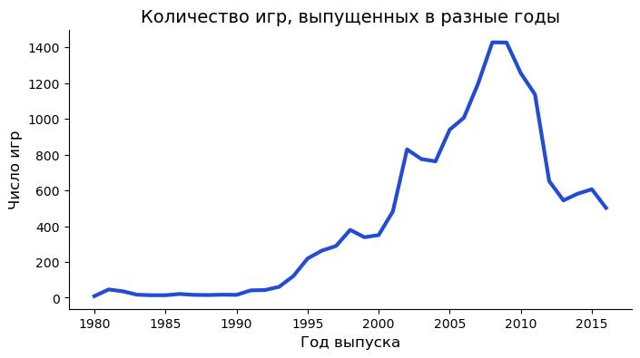

```python
fig = plt.figure(figsize=(8, 4))
ax1 = fig.add_subplot(1, 1, 1)
ax1.spines['top'].set_visible(False)
ax1.spines['right'].set_visible(False)
(games_df
     .pivot_table(index='year_of_release',
                  values='platform',
                  aggfunc='count').reset_index()
     .plot(x='year_of_release',
           y='platform',
           kind='line',
           color='#244cd1',
           legend=False,
           ax=ax1,
           linewidth=3)
)
plt.title('Количество игр, выпущенных в разные годы', fontsize=14)
plt.ylabel('count')

plt.xlabel('Год выпуска', fontsize=12)
plt.ylabel('Число игр', fontsize=12)
plt.show()
# вывод графика с информацией о количестве игр, выпущенных в разные годы
```

В период с 1980 до 1990 гг. рынок игр начал своё постепенное развитие, стали появляться домашние компьютеры и специалисты в области разработки. Уже были популярны игровые консоли и аркадные игры. В конце 1989 г. после выпуска игровой системы "GameBoy" зародился рынок портативных консолей.

На графике видно, что **с 1997 г.** количество выпускаемых игр **начинает активно расти** и достигает пика к 2009 г.. В этот промежуток времени стали внедряться "CD-ROM" для хранения данных, а также новые операционные системы. Большее распространение получил интернет. Набирает популярность рынок мобильных игр с того момента, когда вышел телефон "Nokia" с игрой "Snake".

**Падение** числа выпущенных игр **после 2009 г.** можно связать с последствиями кризиса 2008 г., также как и с нарастающей популярностью мобильных игр и появлением облачных и "VR" технологий. При этом, постепенно начала сменяться парадигма в пользу качества игр, а не их количества.

### Посмотрите, как менялись продажи по платформам. Выберите платформы с наибольшими суммарными продажами и постройте распределение по годам. За какой характерный срок появляются новые и исчезают старые платформы?

```python
platform_total_sales = games_df.pivot_table(index='year_of_release',
                                            columns='platform',
                                            values='total_sales',
                                            aggfunc='sum')
# создание сводной таблицы с суммой глобальных продаж в зависимости от года и платформы
```

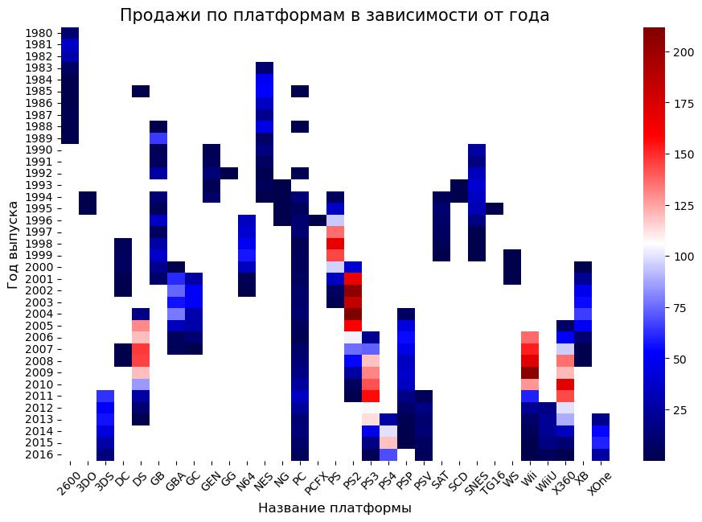

```python
fig = plt.figure(figsize=(11, 7))
ax1 = fig.add_subplot(1, 1, 1)
sns.heatmap(platform_total_sales, ax=ax1, cmap='seismic')
plt.title('Продажи по платформам в зависимости от года', fontsize=15)
plt.xticks(rotation = 45)

plt.ylabel('Год выпуска', fontsize=12)
plt.xlabel('Название платформы', fontsize=12)
plt.show()
# построение тепловой карты
```

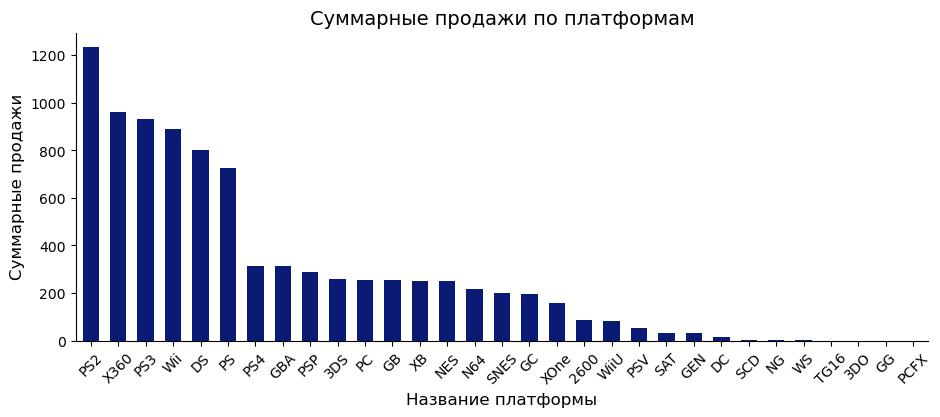

```python
fig = plt.figure(figsize=(11, 4))
ax1 = fig.add_subplot(1, 1, 1)
ax1.spines['top'].set_visible(False)
ax1.spines['right'].set_visible(False)
(games_df
     .pivot_table(index='platform',
                  values='total_sales',
                  aggfunc='sum')
     .sort_values(by='total_sales', ascending=False)
     .plot(y='total_sales',
           kind='bar',
           color='#0b1b75',
           legend=False,
           ax=ax1,
           width=0.6)
)
plt.title('Суммарные продажи по платформам', fontsize=14)
plt.ylabel('total_sales')
plt.xticks(rotation = 45)

plt.xlabel('Название платформы', fontsize=12)
plt.ylabel('Суммарные продажи', fontsize=12)
plt.show()
# построение столбчатой диараммы с зависимостью суммарных продаж от платформы
```

```python
sales_top_list = (games_df
     .pivot_table(index='platform',
                  values='total_sales',
                  aggfunc='sum')
     .sort_values(by='total_sales',
                  ascending=False)
     .head(6).index.to_list()
)
sales_top_list
# создание списка "Топ-6" платформ с наибольшими суммарными продажами
```

```
['PS2', 'X360', 'PS3', 'Wii', 'DS', 'PS']
```

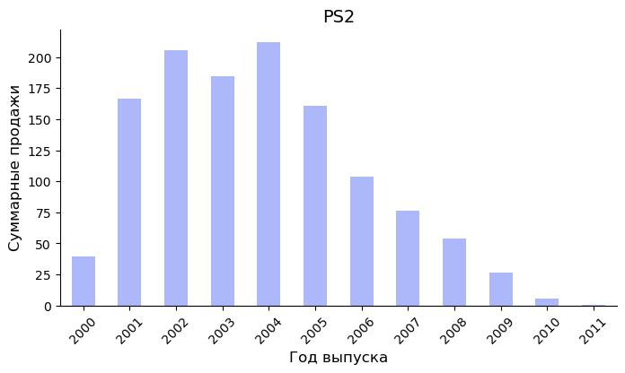

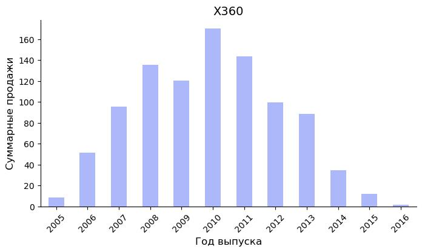

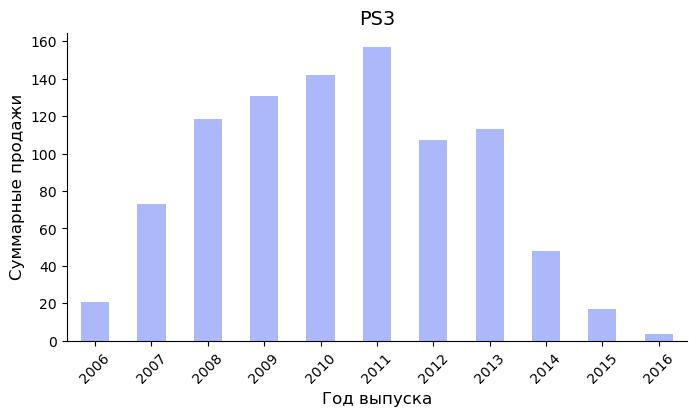

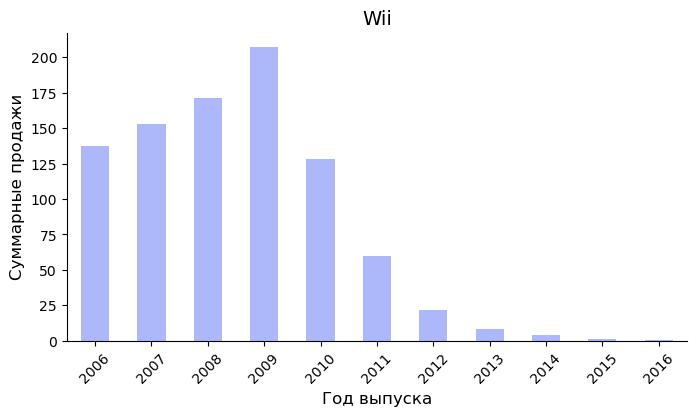

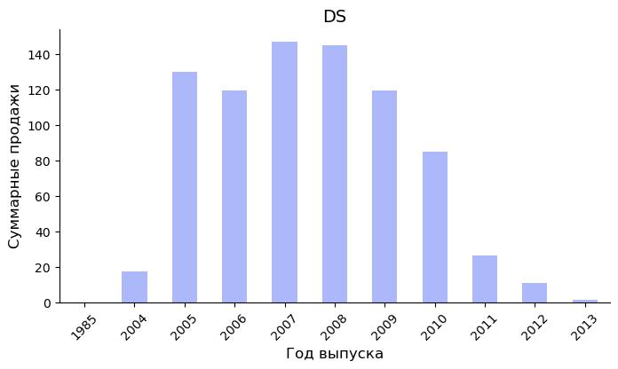

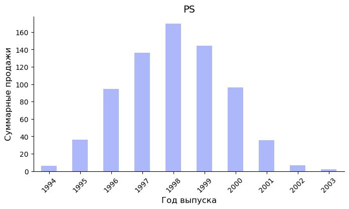

```python
for name in sales_top_list:
    fig = plt.figure(figsize=(8, 4))
    ax1 = fig.add_subplot(1, 1, 1)
    ax1.spines['top'].set_visible(False)
    ax1.spines['right'].set_visible(False)
    (games_df[games_df['platform'] == name]
         .pivot_table(index='year_of_release',
                      values='total_sales',
                      aggfunc='sum')
         .plot(y='total_sales',
               kind='bar',
               color='#acb8fa',
               legend=False,
               ax=ax1)
    )
    plt.title(name, fontsize=14)
    plt.ylabel('total_sales')
    plt.xticks(rotation = 45)

    plt.xlabel('Год выпуска', fontsize=12)
    plt.ylabel('Суммарные продажи', fontsize=12)
    plt.show()
# построение столбчатых диаграмм с суммарными продажами по годам для разных платформ с использованием цикла
```

По суммарным глобальным продажам за всё время лидируют 6 платформ: **"PS2", "X360", "PS3", "Wii", "DS" и "PS"**. В частности, для платформы "PS2" было продано *1.2 млрд.* копий по всему миру.

Однако, на тепловой карте видно, что в последние годы "PS2", "Wii", "PS" и "DS" уже потеряли свою популярность. "PS3" и "X360" также становятся менее востребованными. Крупные производители начинают выпускать обновлённые версии своих платформ уже через 6-7 лет после выпуска предыдущих версий. Из этого можно сделать вывод, что **"жизненный срок"** платформы составляет примерно **от 9 до 11 лет**.

За **актуальный период** можно взять **данные с 2013 по 2016 гг.**. Поскольку после выхода платформы на рынок расцвет её продаж приходится на 5-6 год, следует рассмотреть срез данных по платформам, которые в 2013 году начали приобретать популярность. Например, платформа "PS4" может достичь пика продаж приблизительно к 2017-2018 г..

### Какие платформы лидируют по продажам, растут или падают?

```python
actual_games_df = games_df.query('year_of_release > 2012')
# получение среза актуальных данных
```

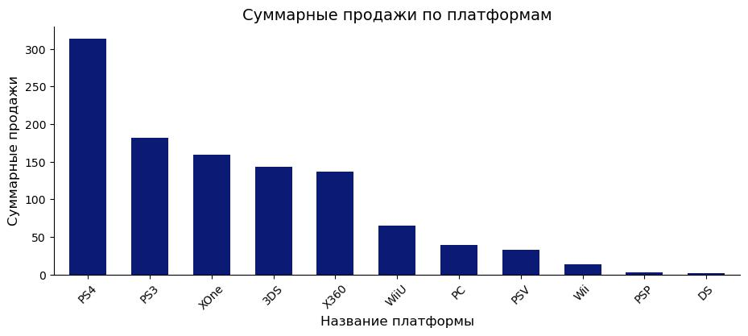

```python
fig = plt.figure(figsize=(11, 4))
ax1 = fig.add_subplot(1, 1, 1)
ax1.spines['top'].set_visible(False)
ax1.spines['right'].set_visible(False)
(actual_games_df
     .pivot_table(index='platform',
                  values='total_sales',
                  aggfunc='sum')
     .sort_values(by='total_sales', ascending=False)
     .plot(y='total_sales',
           kind='bar',
           color='#0b1b75',
           legend=False,
           ax=ax1,
           width=0.6)
)
plt.title('Суммарные продажи по платформам', fontsize=14)
plt.ylabel('total_sales')
plt.xticks(rotation = 45)

plt.ylabel('Суммарные продажи', fontsize=12)
plt.xlabel('Название платформы', fontsize=12)
plt.show()
# построение столбчатой диараммы с зависимостью суммарных продаж от платформы по актуальным данным
```

```python
actual_platform_list = list(actual_games_df['platform'].unique())
print(actual_platform_list)
# создание списка с уникальными названиями платформ с наибольшими суммарными продажами по актуальным данным
top_actual_platform_list = (actual_games_df
                            .pivot_table(index='platform',
                                         values='total_sales',
                                         aggfunc='sum')
                            .sort_values(by='total_sales', ascending=False).head(6).index.to_list()
                           )
print(top_actual_platform_list)
# создание списка "Топ-6" платформ с наибольшими суммарными продажами по актуальным данным
```

```
['PS3', 'X360', 'PS4', '3DS', 'XOne', 'WiiU', 'Wii', 'PC', 'PSV', 'DS', 'PSP']
['PS4', 'PS3', 'XOne', '3DS', 'X360', 'WiiU']
```

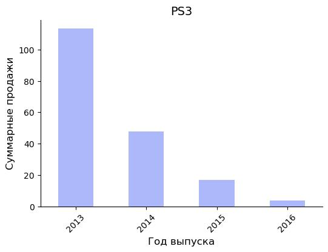

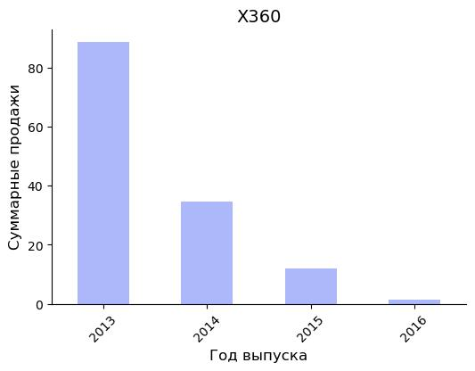

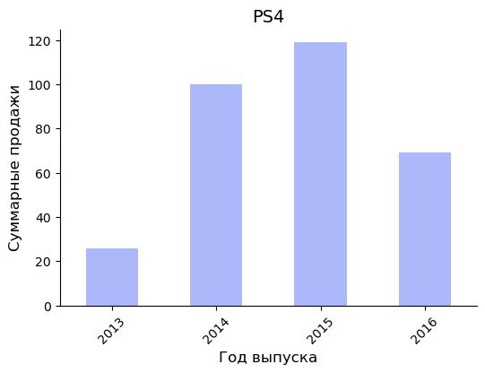

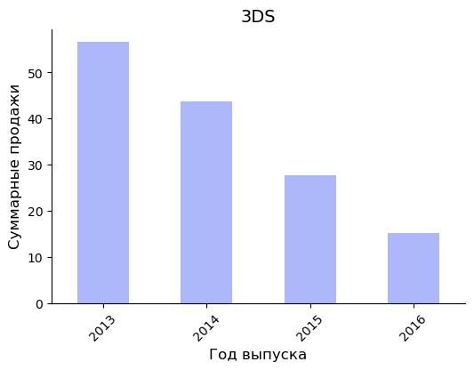

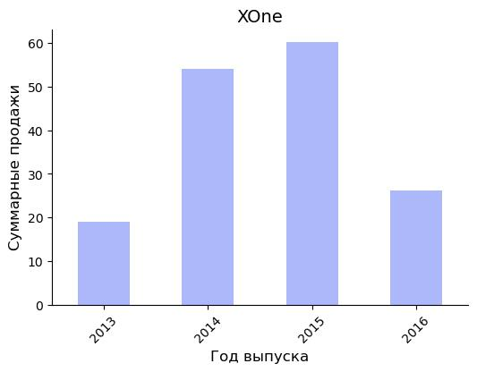

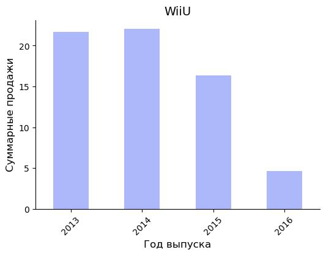

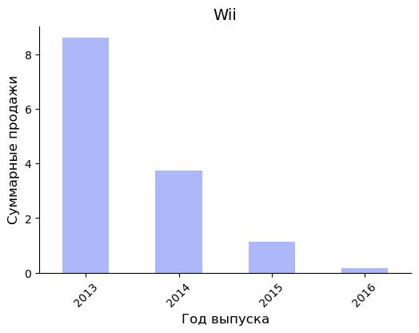

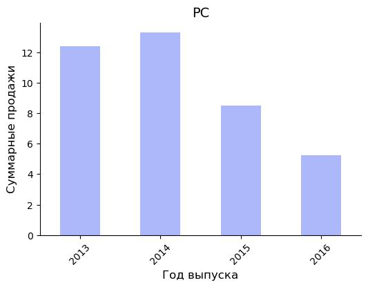

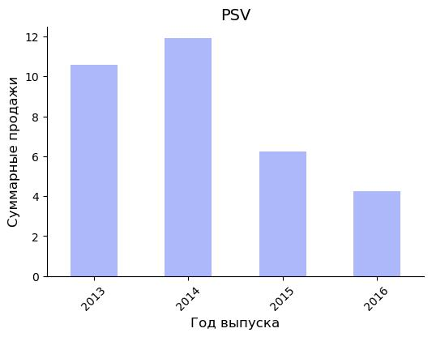

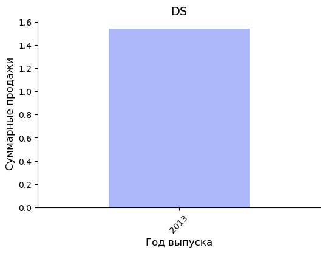

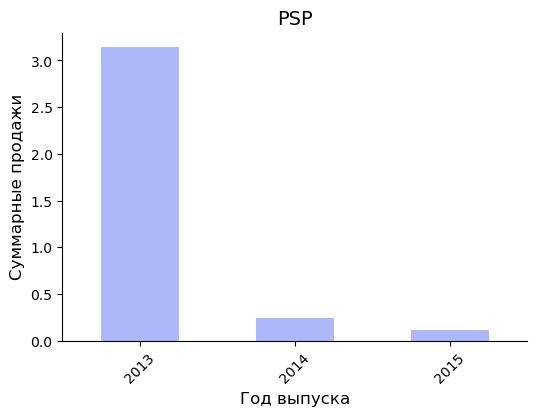

```python
for name in actual_platform_list:
    fig = plt.figure(figsize=(6, 4))
    ax1 = fig.add_subplot(1, 1, 1)
    ax1.spines['top'].set_visible(False)
    ax1.spines['right'].set_visible(False)
    (actual_games_df[actual_games_df['platform'] == name]
         .pivot_table(index='year_of_release',
                      values='total_sales',
                      aggfunc='sum')
         .plot(y='total_sales',
               kind='bar',
               color='#acb8fa',
               legend=False,
               ax=ax1)
    )
    plt.title(name, fontsize=14)
    plt.ylabel('total_sales')
    plt.xticks(rotation = 45)

    plt.xlabel('Год выпуска', fontsize=12)
    plt.ylabel('Суммарные продажи', fontsize=12)
    plt.show()
# построение столбчатых диаграмм с суммарными продажами по годам для разных платформ по актуальным данным
```

Платформы "PSP", "DS", "PS3" и "Wii" уже практически изжили себя.

### Постройте график «ящик с усами» по глобальным продажам игр в разбивке по платформам.

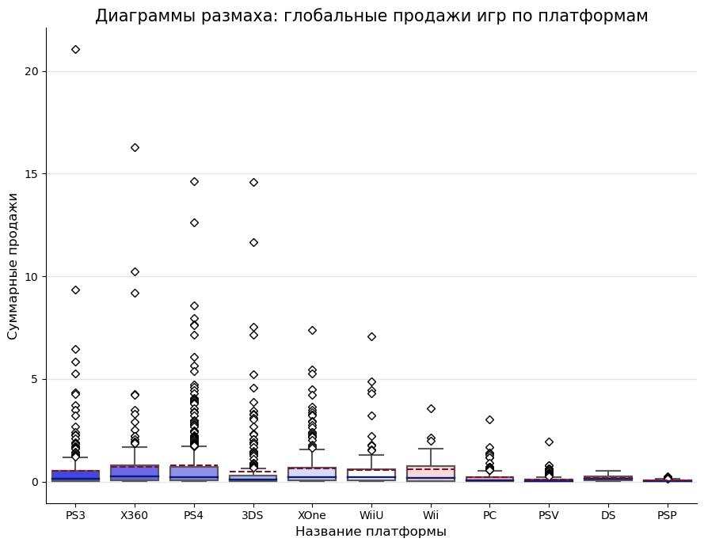

```python
fig = plt.figure(figsize=(9,7))
ax1 = fig.add_subplot(1,1,1)
ax1.set_title('Диаграммы размаха: глобальные продажи игр по платформам', fontsize=15)
ax1.grid(which='major', linewidth=1, color='gray', alpha=0.2)
ax1.spines['top'].set_visible(False)
ax1.spines['right'].set_visible(False)
sns.boxplot(x='platform',
            y='total_sales',
            data=actual_games_df,
            ax=ax1,
            showmeans=True,
            meanline=True,
            medianprops=dict(linewidth=1.7,
                             color='#0b1b75'),
            flierprops=dict(marker='D',
                            markerfacecolor='white',
                            markeredgecolor='black',
                            linewidth=3),
            boxprops=dict(linewidth=1.6),
            meanprops=dict(linewidth=1.5,
                           color='#800f2f'),
            palette='bwr')

plt.xlabel('Название платформы', fontsize=12)
plt.ylabel('Суммарные продажи', fontsize=12)
plt.tight_layout()
plt.show()
# построение диаграмм размаха: глобальные продажи игр по платформам
```

На диаграмах размаха для каждой платформы можно увидеть единичные выбросы (игры с рекордными продажами). Например, игра "Grand Theft Auto V" для платформы "PS3" разошлась по миру в количестве 21 млн. проданных копий. Именно такие игры влияют на средние показатели продаж, смещая их вверх.

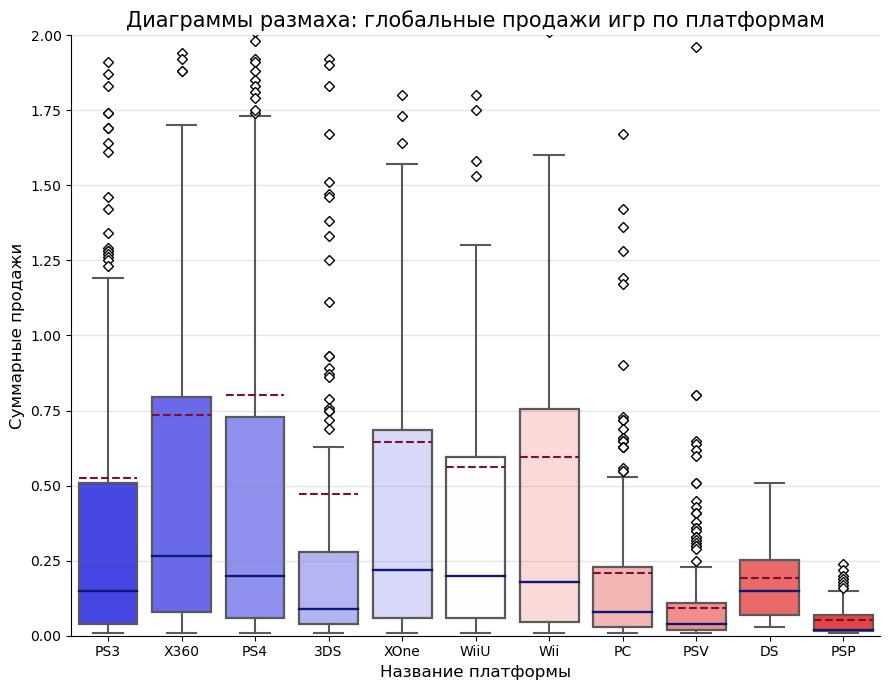

```python
fig = plt.figure(figsize=(9,7))
ax1 = fig.add_subplot(1,1,1)
ax1.set_title('Диаграммы размаха: глобальные продажи игр по платформам', fontsize=15)
ax1.grid(which='major', linewidth=1, color='gray', alpha=0.2)
ax1.spines['top'].set_visible(False)
ax1.spines['right'].set_visible(False)
sns.boxplot(x='platform',
            y='total_sales',
            data=actual_games_df,
            ax=ax1,
            showmeans=True,
            meanline=True,
            medianprops=dict(linewidth=1.7,
                             color='#0b1b75'),
            flierprops=dict(marker='D',
                            markerfacecolor='white',
                            markeredgecolor='black',
                            linewidth=3),
            boxprops=dict(linewidth=1.6),
            meanprops=dict(linewidth=1.5,
                           color='#800f2f'),
            palette='bwr').set(ylim=(0, 2))

plt.xlabel('Название платформы', fontsize=12)
plt.ylabel('Суммарные продажи', fontsize=12)
plt.tight_layout()
plt.show()
# построение диаграмм размаха: глобальные продажи игр по платформам
```

В то же время, специфику рынка игр отражает большая разница между медианными и средними значениями. Это можно объяснить наличием **самых продаваемых и популярных игр** на рынке, которые могут перевыпускаться для разных платформ и продаваться в течение длительного периода времени. В данной выборке больше всего таких игр у платформ **"PS4" и "X360"**.

### Как влияют на продажи внутри одной популярной платформы отзывы пользователей и критиков?

```python
def print_total_sales_and_scores_correlations(platform_name, ylim=[0, 5]):
    fig = plt.figure(figsize=(12, 5))
    fig.suptitle(platform_name, fontsize=14)
    ax1 = fig.add_subplot(1, 2, 1)
    ax1.set_ylim(ylim)
    ax1.set_title('Разброс оценок критиков', fontsize=14)
    ax2 = fig.add_subplot(1, 2, 2)
    ax2.set_ylim(ylim)
    ax2.set_title('Разброс оценок пользователей', fontsize=14)
    ax1.spines['top'].set_visible(False)
    ax1.spines['right'].set_visible(False)
    ax2.spines['top'].set_visible(False)
    ax2.spines['right'].set_visible(False)
    ax1.set_ylabel('Суммарные продажи', fontsize=12)
    ax2.set_ylabel('Суммарные продажи', fontsize=12)
    sns.scatterplot(y='total_sales',
                    x='critic_score',
                    data=actual_games_df[actual_games_df['platform'] == platform_name],
                    color='#0b1b75',
                    ax=ax1)
    sns.scatterplot(y='total_sales',
                    x='user_score',
                    data=actual_games_df[actual_games_df['platform'] == platform_name],
                    color='#800f2f',
                    ax=ax2)

    plt.tight_layout()
    return plt.show()
# создание функции для построения диаграмм рассеяния

def count_total_sales_and_scores_correlations(platform_name):
    correlation_critic_score = actual_games_df[actual_games_df['platform'] == platform_name]['critic_score'].corr(actual_games_df[actual_games_df['platform'] == platform_name]['total_sales'])
    correlation_user_score = actual_games_df[actual_games_df['platform'] == platform_name]['user_score'].corr(actual_games_df[actual_games_df['platform'] == platform_name]['total_sales'])
    print(f'Корреляция между оценками критиков и глобальными продажами для платформы {platform_name}: {round(correlation_critic_score, 3)}')
    print(f'Корреляция между оценками пользователей и глобальными продажами для платформы {platform_name}: {round(correlation_user_score, 3)}')
# создание функции для подсчёта корреляций
```

[figure not shown]

```
Корреляция между оценками критиков и глобальными продажами для платформы PS4: 0.407
Корреляция между оценками пользователей и глобальными продажами для платформы PS4: -0.032
```

```python
print_total_sales_and_scores_correlations('PS4')
count_total_sales_and_scores_correlations('PS4')
# применение функций для платформы "PS4"
```

Корреляция между оценками пользователей и глобальными продажами для платформы "PS4" отсутствует, а **корреляция с оценками критиков - умеренная**.

[figure not shown]

```
Корреляция между оценками критиков и глобальными продажами для платформы PS4: 0.407
Корреляция между оценками пользователей и глобальными продажами для платформы PS4: -0.032
```

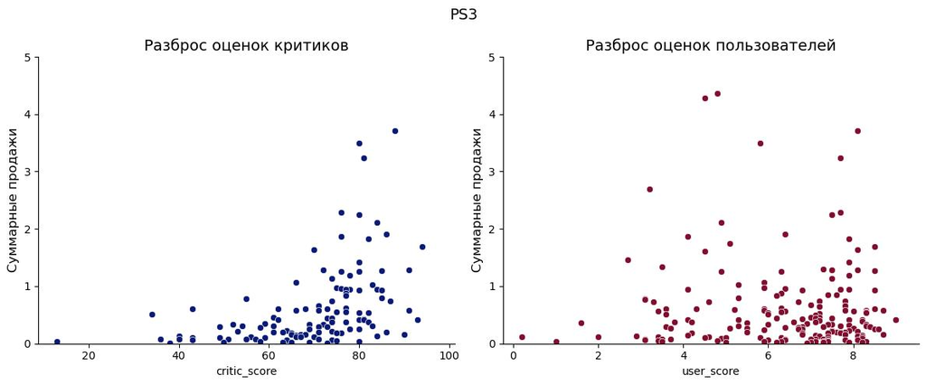

```
Корреляция между оценками критиков и глобальными продажами для платформы PS3: 0.334
Корреляция между оценками пользователей и глобальными продажами для платформы PS3: 0.002
```

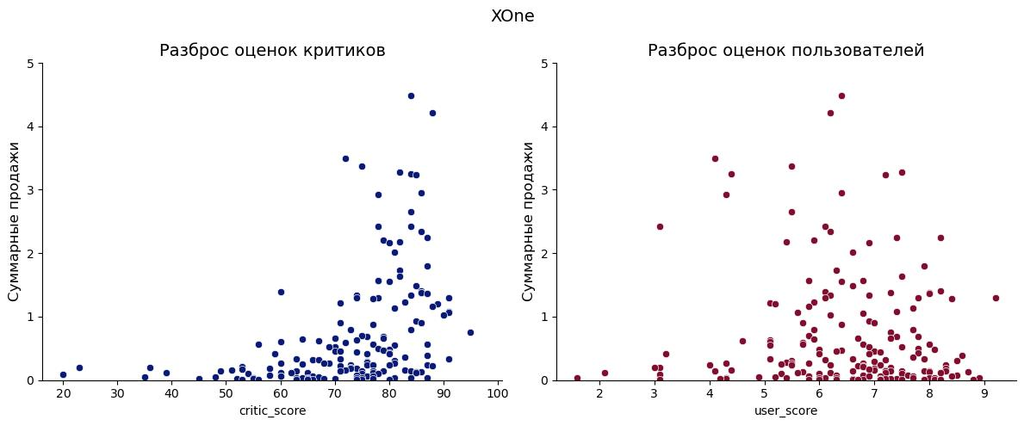

```
Корреляция между оценками критиков и глобальными продажами для платформы XOne: 0.417
Корреляция между оценками пользователей и глобальными продажами для платформы XOne: -0.069
```

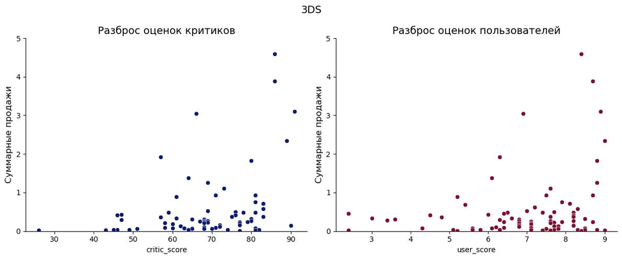

```
Корреляция между оценками критиков и глобальными продажами для платформы 3DS: 0.357
Корреляция между оценками пользователей и глобальными продажами для платформы 3DS: 0.242
```

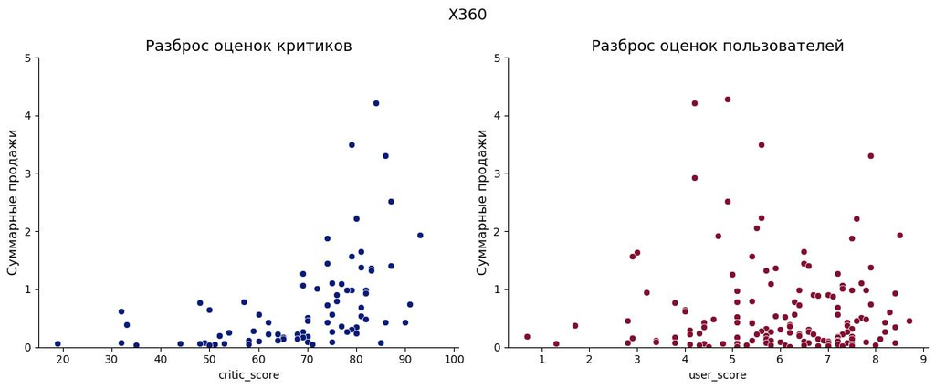

```
Корреляция между оценками критиков и глобальными продажами для платформы X360: 0.35
Корреляция между оценками пользователей и глобальными продажами для платформы X360: -0.012
```

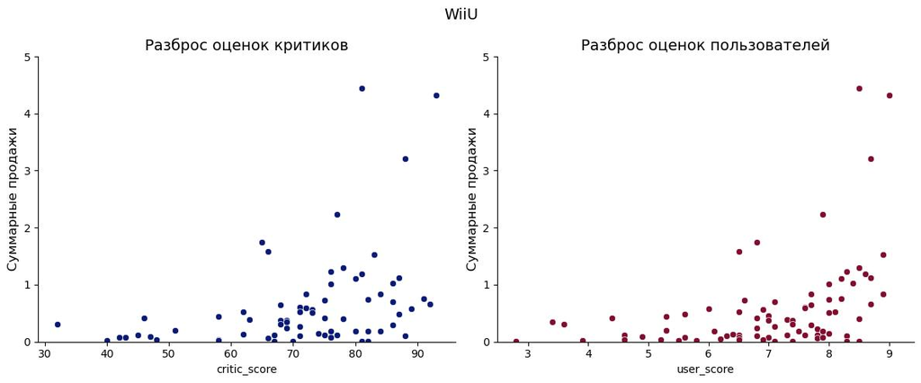

```
Корреляция между оценками критиков и глобальными продажами для платформы WiiU: 0.376
Корреляция между оценками пользователей и глобальными продажами для платформы WiiU: 0.419
```

```python
for name in top_actual_platform_list:
    print_total_sales_and_scores_correlations(name)
    count_total_sales_and_scores_correlations(name)
# применение функций для "Топ-6" платформ по глобальным продажам
```

Единственное исключение - платформа "WiiU". Для неё корреляция продаж с оценками пользователей равна 0.419.